# Project 1: Wrangling, Exploration, Visualization

SDS322E

## Data Wrangling, Exploration, Visualization

### Arpan Patel, adp2999

#### Introduction

Hello.. For this project, I have decided to compare my Amazon order data with the S&P 500, year to date. I think it will interesting comparing patterns among the two datasets. The ‘AMZM_orders’ dataset contains the variables: Order Date, Order ID, Account Group, Order Quantity, Order Subtotal, Order Tax, Order Net Total, Amazon-Internal Product Category, ASIN, Title, UNSPSC, Brand, Manufacturer, Seller Name, and Seller State. The ‘SP500’ dataset contains the variables: Date, Open, High, Low, Close, Adj Close, and Volume. The idea is to compare frequency of orders with several S&P indicators such as opening value, closing value, and volume. Some other interesting comparisons may come up as I complete the project. The common ID variable that I will be using is the date. The Amazon order data was acquired by selecting and downloading the data from the privacy section of my account. The S&P 500 year to date data was acquired from Yahoo Finance. I expect to find a positive relationship between the % change on the day and my amazon order history. More specifically, I expect to find that I spend more on Amazon on days that the S&P has a higher percent change (a green day).

```r
# read your datasets in here, e.g., with read_csv()
library(tidyverse)
AMZM_orders <- read_csv("/stor/home/adp2999/project1/AMZM_orders.csv",
    col_types = cols(`Order Date` = col_date(format = "%m/%d/%Y"),
        `Order Quantity` = col_integer(), `Order Subtotal` = col_number(),
        `Order Tax` = col_number(), `Order Net Total` = col_number(),
        UNSPSC = col_integer()))
SP500 <- read_csv("/stor/home/adp2999/project1/SP500.csv", col_types = cols(Date = col_date(format = "%b %d, %Y"),
    Open = col_number(), High = col_number(), Low = col_number(),
    `Close*` = col_number(), `Adj Close**` = col_number(), Volume = col_number()))

head(AMZM_orders)
```

```
## # A tibble: 6 x 16
##   `Order Date` `Order ID` `Account Group` `Order Quantity` `Order Subtotal`
##   <date>       <chr>      <chr>                      <int>            <dbl>
## 1 2021-10-27   111-59113… BrightChild                    3            120.
## 2 2021-10-14   112-54522… BrightChild                    2             31.6
## 3 2021-10-14   112-54522… BrightChild                    2             31.6
## 4 2021-10-13   114-82326… BrightChild                    1             55.0
## 5 2021-10-13   114-04930… BrightChild                    2             26.0
## 6 2021-10-11   114-29492… BrightChild                    2             22.0
## # … with 11 more variables: `Order Tax` <dbl>, `Order Net Total` <dbl>,
## #   `Amazon-Internal Product Category` <chr>, ASIN <chr>, Title <chr>,
## #   UNSPSC <int>, Brand <chr>, Manufacturer <chr>, `Item model number` <chr>,
## #   `Seller Name` <chr>, `Seller State` <chr>
```

```r
head(SP500)
```

```
## # A tibble: 6 x 7
##   Date        Open  High   Low `Close*` `Adj Close**`     Volume
##   <date>     <dbl> <dbl> <dbl>    <dbl>         <dbl>      <dbl>
## 1 2021-10-29 4573. 4608. 4568.    4605.         4605. 3632260000
## 2 2021-10-28 4563. 4598. 4563.    4596.         4596. 3197560000
## 3 2021-10-27 4580. 4585. 4552.    4552.         4552. 3259510000
## 4 2021-10-26 4579. 4599. 4569.    4575.         4575. 2866500000
## 5 2021-10-25 4554. 4573. 4537.    4566.         4566. 3250210000
## 6 2021-10-22 4546. 4560. 4524     4545.         4545. 3062810000
```

Here I formatted the data column in both datasets into a common format so when I join the datasets, the join process will be seamless. I also used the import dataset function on R to changed the class of variables ahead of time. Finally, I outputted the datasets so you can see what the raw data looks like. In short, the ‘AMZM_orders’ has 217 observations of 16 variables. The ‘SP500’ dataset has 209 observations of 7 variables.

#### Tidying: Reshaping

```r
# your tidying code. Here I deleted all observations that had
# an NA and renamed 'Order Date' to 'Date' for a common ID
# between the two data sets.
AMZM_orders <- rename(AMZM_orders, Date = "Order Date")
SP500 <- rename(SP500, Close = "Close*")
head(AMZM_orders)
```

```
## # A tibble: 6 x 16
##   Date       `Order ID` `Account Group` `Order Quantity` `Order Subtotal`
##   <date>     <chr>      <chr>                      <int>            <dbl>
## 1 2021-10-27 111-59113… BrightChild                    3            120.
## 2 2021-10-14 112-54522… BrightChild                    2             31.6
## 3 2021-10-14 112-54522… BrightChild                    2             31.6
## 4 2021-10-13 114-82326… BrightChild                    1             55.0
## 5 2021-10-13 114-04930… BrightChild                    2             26.0
## 6 2021-10-11 114-29492… BrightChild                    2             22.0
## # … with 11 more variables: `Order Tax` <dbl>, `Order Net Total` <dbl>,
## #   `Amazon-Internal Product Category` <chr>, ASIN <chr>, Title <chr>,
## #   UNSPSC <int>, Brand <chr>, Manufacturer <chr>, `Item model number` <chr>,
## #   `Seller Name` <chr>, `Seller State` <chr>
```

```r
head(SP500)
```

```
## # A tibble: 6 x 7
##   Date        Open  High   Low Close `Adj Close**`     Volume
##   <date>     <dbl> <dbl> <dbl> <dbl>         <dbl>      <dbl>
## 1 2021-10-29 4573. 4608. 4568. 4605.         4605. 3632260000
## 2 2021-10-28 4563. 4598. 4563. 4596.         4596. 3197560000
## 3 2021-10-27 4580. 4585. 4552. 4552.         4552. 3259510000
## 4 2021-10-26 4579. 4599. 4569. 4575.         4575. 2866500000
## 5 2021-10-25 4554. 4573. 4537. 4566.         4566. 3250210000
## 6 2021-10-22 4546. 4560. 4524  4545.         4545. 3062810000
```

```r
# I will tidy data after wrangling section.
AMZM_orders2 <- AMZM_orders %>% pivot_wider(names_from = `Amazon-Internal Product Category`,
    values_from = "Brand")
AMZM_orders3 <- AMZM_orders2 %>% pivot_longer(15:43, names_to = "Amazon-Internal Product Category",
    values_to = "Brand")
```

Since my datasets were already tidy, I will use the required functions in the wrangling section. I used this section of the project to rename the variable “Order Date” to “Date” so both datasets can have a common ID of “Date”. I did not need to clean my data by using na.omit() because neither dataset had any NAs in rows of interest.

#### Joining/Merging

```r
# your joining code
data1 <- right_join(AMZM_orders, SP500, by = "Date")
head(data1)
```

```
## # A tibble: 6 x 22
##   Date       `Order ID` `Account Group` `Order Quantity` `Order Subtotal`
##   <date>     <chr>      <chr>                      <int>            <dbl>
## 1 2021-10-27 111-59113… BrightChild                    3            120.
## 2 2021-10-14 112-54522… BrightChild                    2             31.6
## 3 2021-10-14 112-54522… BrightChild                    2             31.6
## 4 2021-10-13 114-82326… BrightChild                    1             55.0
## 5 2021-10-13 114-04930… BrightChild                    2             26.0
## 6 2021-10-11 114-29492… BrightChild                    2             22.0
## # … with 17 more variables: `Order Tax` <dbl>, `Order Net Total` <dbl>,
## #   `Amazon-Internal Product Category` <chr>, ASIN <chr>, Title <chr>,
## #   UNSPSC <int>, Brand <chr>, Manufacturer <chr>, `Item model number` <chr>,
## #   `Seller Name` <chr>, `Seller State` <chr>, Open <dbl>, High <dbl>,
## #   Low <dbl>, Close <dbl>, `Adj Close**` <dbl>, Volume <dbl>
```

```r
# your joining code
compare <- anti_join(AMZM_orders, SP500)
head(compare)
```

```
## # A tibble: 6 x 16
##   Date       `Order ID` `Account Group` `Order Quantity` `Order Subtotal`
##   <date>     <chr>      <chr>                      <int>            <dbl>
## 1 2021-10-09 113-16447… BrightChild                    2           693.
## 2 2021-09-25 113-97922… BrightChild                    1            15.6
## 3 2021-09-25 113-88430… BrightChild                    1            16.4
## 4 2021-09-19 113-47329… BrightChild                    1            12
## 5 2021-09-18 114-65528… BrightChild                    1             8.99
## 6 2021-09-18 114-34861… BrightChild                    4           100.
## # … with 11 more variables: `Order Tax` <dbl>, `Order Net Total` <dbl>,
## #   `Amazon-Internal Product Category` <chr>, ASIN <chr>, Title <chr>,
## #   UNSPSC <int>, Brand <chr>, Manufacturer <chr>, `Item model number` <chr>,
## #   `Seller Name` <chr>, `Seller State` <chr>
```

```r
count(compare)
```

```
## # A tibble: 1 x 1
##       n
##   <int>
## 1    54
```

```r
compare2 <- anti_join(SP500, AMZM_orders)
head(compare2)
```

```
## # A tibble: 6 x 7
##   Date        Open  High   Low Close `Adj Close**`     Volume
##   <date>     <dbl> <dbl> <dbl> <dbl>         <dbl>      <dbl>
## 1 2021-10-29 4573. 4608. 4568. 4605.         4605. 3632260000
## 2 2021-10-28 4563. 4598. 4563. 4596.         4596. 3197560000
## 3 2021-10-26 4579. 4599. 4569. 4575.         4575. 2866500000
## 4 2021-10-25 4554. 4573. 4537. 4566.         4566. 3250210000
## 5 2021-10-22 4546. 4560. 4524  4545.         4545. 3062810000
## 6 2021-10-21 4532. 4551. 4527. 4550.         4550. 3016950000
```

```r
count(compare2)
```

```
## # A tibble: 1 x 1
##       n
##   <int>
## 1   127
```

Since I want to compare Amazon orders to the S&P 500, I need to do a right join where I keep all the rows from ‘SP500’ and only add rows with matches from ‘AMZM_orders’. This way the rows in ‘SP500’ with no match in ‘AMZM_orders’ will have NAs in the new columns. In other words, I can compare the percent change of the S&P on every day, year to date, to my Amazon order history, even on days where I did not order anything.

Before the join, the ‘AMZM_orders’ dataset had 217 observations of 16 variables (15 of which were unique). In addition, the ‘SP500’ dataset had 209 observations of 7 variables (6 of which were unique). The only common ID/variable was ‘Date’. The IDs that were unique to ‘AMZM_orders’ are Order ID, Account Group, Order Quantity, Order Subtotal, Order Tax, Order Net Total, Amazon-Internal Product Category, ASIN, Title, UNSPSC, Brand, Manufacturer, Seller Name, and Seller State. The IDs that were unique to ‘SP500’ are Open, High, Low, Close, Adj Close, and Volume. After the right join, the resulting ‘data1’ had 290 observations of 22 variables. In theory, after a right-join, the result should have the same number of rows as ‘SP500’ (209 rows). However, the resulting ‘data1’ has 290 rows. This is because there are multiple Amazon orders on the same day. This results in ‘SP500’ data being copied multiple times during the join. To be exact, there were 81 times in which I ordered multiple items on the same day. From the anti-join code, there are 54 observations in ‘AMZM_orders’ that have no match in ‘SP500’. There are also 127 observations in the ‘SP500’ dataset that have no match in ‘AMZM_orders’.

#### Wrangling

```r
# your mutate code
data2 <- data1
data2 <- data2 %>% mutate(day_change = Close - Open)
data2 <- data2 %>% mutate(percent_day_change = ((day_change)/(Open)) *
    100)
```

First, I made a copy of ‘data1’ and called it ‘data2’ in case I mess up the mutate() function. My first mutate function, I calculated the day change by subtracting the closing value with the opening value. However, I realized a better metric for the S&P 500 would be percent day change. So I used mutate again to create this variable.

```r
# your filter code
data2$`Order Quantity`[is.na(data2$`Order Quantity`)] <- 0
data2 %>% filter(`Order Quantity` == "0", percent_day_change <
    0)
```

```
## # A tibble: 61 x 24
##    Date       `Order ID` `Account Group` `Order Quantity` `Order Subtotal`
##    <date>     <chr>      <chr>                      <dbl>            <dbl>
##  1 2021-09-08 114-41723… BrightChild                    0                0
##  2 2021-09-08 114-69823… BrightChild                    0                0
##  3 2021-05-05 111-02249… BrightChild                    0                0
##  4 2021-01-22 111-09908… BrightChild                    0                0
##  5 2021-10-26 <NA>       <NA>                           0               NA
##  6 2021-10-22 <NA>       <NA>                           0               NA
##  7 2021-10-12 <NA>       <NA>                           0               NA
##  8 2021-09-30 <NA>       <NA>                           0               NA
##  9 2021-09-29 <NA>       <NA>                           0               NA
## 10 2021-09-21 <NA>       <NA>                           0               NA
## # … with 51 more rows, and 19 more variables: `Order Tax` <dbl>, `Order Net
## #   Total` <dbl>, `Amazon-Internal Product Category` <chr>, ASIN <chr>,
## #   Title <chr>, UNSPSC <int>, Brand <chr>, Manufacturer <chr>, `Item model
## #   number` <chr>, `Seller Name` <chr>, `Seller State` <chr>, Open <dbl>,
## #   High <dbl>, Low <dbl>, Close <dbl>, `Adj Close**` <dbl>, Volume <dbl>,
## #   day_change <dbl>, percent_day_change <dbl>
```

```r
# your select and arrange code
data2 %>% select(`Order Net Total`, `Amazon-Internal Product Category`) %>%
    arrange(desc(`Order Net Total`))
```

```
## # A tibble: 290 x 2
##    `Order Net Total` `Amazon-Internal Product Category`
##                <dbl> <chr>
##  1              660. Personal Computer
##  2              647. Business, Industrial, & Scientific Supplies Basic
##  3              647. Personal Computer
##  4              565. Personal Computer
##  5              467. Personal Computer
##  6              465. Office Product
##  7              429. Personal Computer
##  8              425. Personal Computer
##  9              425. Personal Computer
## 10              382. Personal Computer
## # … with 280 more rows
```

```r
# your wrangling code
data2 %>% filter(`Order Quantity` > 1) %>% select(`Order Quantity`,
    `Order Net Total`, `Amazon-Internal Product Category`, `Seller State`) %>%
    arrange(desc(`Order Net Total`))
```

```
## # A tibble: 39 x 4
##    `Order Quantity` `Order Net Total` `Amazon-Internal Product C… `Seller State`
##               <dbl>             <dbl> <chr>                       <chr>
##  1                2             660.  Personal Computer           Guangdong
##  2                3             647.  Business, Industrial, & Sc… guangdong
##  3                3             647.  Personal Computer           guangdongsheng
##  4                2             425.  Personal Computer           FL
##  5                2             425.  Personal Computer           FL
##  6                2             213.  Personal Computer           Washington
##  7                3             127.  Speakers                    NJ
##  8                2              95.7 Home Improvement            Washington
##  9                2              95.7 Home Improvement            <NA>
## 10                2              87.2 Health and Beauty           GA
## # … with 29 more rows
```

In this wrangle, I wanted to see several things. First, I wanted to see where the most expensive items I was buying was coming from. As you can see from the chart above, the top 3 most expensive items I have bought year to date are from Guangdong, China. I also wanted to see what type of items I am buying in quantities higher than 1. From the data above, we can see that personal computer is still the highest price and quantity category. This makes sense because I purchase several laptops a week for my business.

```r
# your summarize/group-by code
data2 %>% group_by(`Amazon-Internal Product Category`) %>% summarize(average_day_change = mean(day_change,
    na.rm = T), n()) %>% arrange(average_day_change)
```

```
## # A tibble: 26 x 3
##    `Amazon-Internal Product Category` average_day_change `n()`
##    <chr>                                           <dbl> <int>
##  1 Grocery                                       -28.1       4
##  2 Digital Video Games                           -20.5       1
##  3 Electronic Gift Card                          -20.5       4
##  4 Home Improvement                              -12.9      10
##  5 Shoes                                         -10.5       6
##  6 Home                                           -7.09      2
##  7 Personal Computer                              -1.93     33
##  8 Speakers                                       -1.40      5
##  9 Musical Instruments                            -0.767     3
## 10 CE                                             -0.660    14
## # … with 16 more rows
```

```r
# your wrangling code
Brand_data <- data2 %>% group_by(`Amazon-Internal Product Category`,
    Brand) %>% summarize(average_order_quantity = mean(`Order Quantity`,
    na.rm = T), n()) %>% arrange(desc(average_order_quantity))
head(Brand_data)
```

```
## # A tibble: 6 x 4
## # Groups:   Amazon-Internal Product Category [5]
##   `Amazon-Internal Product Categor… Brand            average_order_quanti… `n()`
##   <chr>                             <chr>                            <dbl> <int>
## 1 Office Product                    AGPTEK                               4     1
## 2 Apparel                           Ekouaer                              3     1
## 3 Beauty                            MAYKI                                3     1
## 4 Beauty                            Rippling Kindne…                     3     1
## 5 Sports                            YUESUO                               3     2
## 6 Toy                               OHill                                3     1
```

```r
# your TIDYING code
data3 <- data2
data3 <- data3 %>% separate("Date", into = c("Year", "Month",
    "Day"), convert = T)
head(data3)
```

```
## # A tibble: 6 x 26
##    Year Month   Day `Order ID` `Account Group` `Order Quantity` `Order Subtotal`
##   <int> <int> <int> <chr>      <chr>                      <dbl>            <dbl>
## 1  2021    10    27 111-59113… BrightChild                    3            120.
## 2  2021    10    14 112-54522… BrightChild                    2             31.6
## 3  2021    10    14 112-54522… BrightChild                    2             31.6
## 4  2021    10    13 114-82326… BrightChild                    1             55.0
## 5  2021    10    13 114-04930… BrightChild                    2             26.0
## 6  2021    10    11 114-29492… BrightChild                    2             22.0
## # … with 19 more variables: `Order Tax` <dbl>, `Order Net Total` <dbl>,
## #   `Amazon-Internal Product Category` <chr>, ASIN <chr>, Title <chr>,
## #   UNSPSC <int>, Brand <chr>, Manufacturer <chr>, `Item model number` <chr>,
## #   `Seller Name` <chr>, `Seller State` <chr>, Open <dbl>, High <dbl>,
## #   Low <dbl>, Close <dbl>, `Adj Close**` <dbl>, Volume <dbl>,
## #   day_change <dbl>, percent_day_change <dbl>
```

After doing the joining and wrangling section, I decided that I needed to tidy my dataset in order to be able to filter by month and find patterns a monthly basis. Therefore, I used the separate() function to separate ‘Date’ into ‘Year’, ‘Month’, and ‘Day’.

```r
# your wrangling code
data3 %>% filter(Month == 6) %>% summarize(mean(`Order Net Total`,
    na.rm = T), min(`Order Net Total`, na.rm = T), max(`Order Net Total`,
    na.rm = T), sd(`Order Net Total`, na.rm = T), var(`Order Net Total`,
    na.rm = T), quantile(`Order Net Total`, na.rm = T), n_distinct(`Order Net Total`),
    n())
```

```
## # A tibble: 5 x 8
##   `mean(\`Order N… `min(\`Order Ne… `max(\`Order Ne… `sd(\`Order Net…
##              <dbl>            <dbl>            <dbl>            <dbl>
## 1             38.7             5.06             220.             52.3
## 2             38.7             5.06             220.             52.3
## 3             38.7             5.06             220.             52.3
## 4             38.7             5.06             220.             52.3
## 5             38.7             5.06             220.             52.3
## # … with 4 more variables: `var(\`Order Net Total\`, na.rm = T)` <dbl>,
## #   `quantile(\`Order Net Total\`, na.rm = T)` <dbl>, `n_distinct(\`Order Net
## #   Total\`)` <int>, `n()` <int>
```

Here, I used at least 5 unique functions within summarize to gain more insight into my data. One notable analytic is the mean price of items bought in the month of June. This turned out to be $38.67.

```r
# your wrangling code
data2 %>% mutate(Date = str_replace(Date, "2021-", ""))
```

```
## # A tibble: 290 x 24
##    Date  `Order ID` `Account Group` `Order Quantity` `Order Subtotal`
##    <chr> <chr>      <chr>                      <dbl>            <dbl>
##  1 10-27 111-59113… BrightChild                    3           120.
##  2 10-14 112-54522… BrightChild                    2            31.6
##  3 10-14 112-54522… BrightChild                    2            31.6
##  4 10-13 114-82326… BrightChild                    1            55.0
##  5 10-13 114-04930… BrightChild                    2            26.0
##  6 10-11 114-29492… BrightChild                    2            22.0
##  7 10-11 114-18237… BrightChild                    1             7.99
##  8 10-11 114-19744… BrightChild                    1           439
##  9 10-11 113-92777… BrightChild                    2           400.
## 10 10-11 112-35955… BrightChild                    2            37.2
## # … with 280 more rows, and 19 more variables: `Order Tax` <dbl>, `Order Net
## #   Total` <dbl>, `Amazon-Internal Product Category` <chr>, ASIN <chr>,
## #   Title <chr>, UNSPSC <int>, Brand <chr>, Manufacturer <chr>, `Item model
## #   number` <chr>, `Seller Name` <chr>, `Seller State` <chr>, Open <dbl>,
## #   High <dbl>, Low <dbl>, Close <dbl>, `Adj Close**` <dbl>, Volume <dbl>,
## #   day_change <dbl>, percent_day_change <dbl>
```

Here is used a `stringr` function in order to remove the year from each observation. Since the whole dataset is only purchases year to date, all of them occurred in 2021. Therefore, having the year is irrelevant.

```r
# your wrangling code
per_million <- function(Volume) {
    volume_per_million <- (Volume/1e+06)
    return(volume_per_million)
}
data3 %>% mutate(Volume = per_million(Volume))
```

```
## # A tibble: 290 x 26
##     Year Month   Day `Order ID` `Account Group` `Order Quantity`
##    <int> <int> <int> <chr>      <chr>                      <dbl>
##  1  2021    10    27 111-59113… BrightChild                    3
##  2  2021    10    14 112-54522… BrightChild                    2
##  3  2021    10    14 112-54522… BrightChild                    2
##  4  2021    10    13 114-82326… BrightChild                    1
##  5  2021    10    13 114-04930… BrightChild                    2
##  6  2021    10    11 114-29492… BrightChild                    2
##  7  2021    10    11 114-18237… BrightChild                    1
##  8  2021    10    11 114-19744… BrightChild                    1
##  9  2021    10    11 113-92777… BrightChild                    2
## 10  2021    10    11 112-35955… BrightChild                    2
## # … with 280 more rows, and 20 more variables: `Order Subtotal` <dbl>, `Order
## #   Tax` <dbl>, `Order Net Total` <dbl>, `Amazon-Internal Product
## #   Category` <chr>, ASIN <chr>, Title <chr>, UNSPSC <int>, Brand <chr>,
## #   Manufacturer <chr>, `Item model number` <chr>, `Seller Name` <chr>, `Seller
## #   State` <chr>, Open <dbl>, High <dbl>, Low <dbl>, Close <dbl>, `Adj
## #   Close**` <dbl>, Volume <dbl>, day_change <dbl>, percent_day_change <dbl>
```

In this chunk of code, I created my own function that converts the ‘Volume’ variable into volume per million. Since the numbers in this column are extremely large, I figured it would be better to look at if the numbers were per million. So that is what I did.

```r
# your wrangling code
library(knitr)
table1 <- data2 %>% group_by(`Amazon-Internal Product Category`) %>%
    summarize(average_day_change = mean(day_change, na.rm = T),
        n()) %>% arrange(average_day_change)
table1 %>% kable()
```

| Amazon-Internal Product Category | average_day_change | n() |
| --- | --- | --- |
| Grocery | -28.0975000 | 4 |
| Digital Video Games | -20.4800000 | 1 |
| Electronic Gift Card | -20.4800000 | 4 |
| Home Improvement | -12.9350000 | 10 |
| Shoes | -10.5150000 | 6 |
| Home | -7.0900000 | 2 |
| Personal Computer | -1.9327273 | 33 |
| Speakers | -1.4020000 | 5 |
| Musical Instruments | -0.7666667 | 3 |
| CE | -0.6600000 | 14 |
| Kitchen | 1.5780000 | 5 |
| Beauty | 2.2900000 | 9 |
| NA | 2.5659843 | 127 |
| Health and Beauty | 5.6283333 | 12 |
| Office Product | 6.2360000 | 5 |
| Automotive Parts and Accessories | 6.8200000 | 1 |
| Wireless | 10.2257143 | 7 |
| Premium Consumer Electronics Brands | 10.6200000 | 1 |
| Apparel | 11.3375000 | 4 |
| Business, Industrial, & Scientific Supplies Basic | 11.5788889 | 9 |
| Book | 15.6083333 | 6 |
| Sports | 15.9276923 | 13 |
| Toy | 16.9900000 | 2 |
| Lawn & Patio | 18.1825000 | 4 |
| Jewelry | 23.3600000 | 1 |
| Prestige Beauty | 40.1750000 | 2 |

Finally, I styled a table using `kable` packages

#### Visualizing

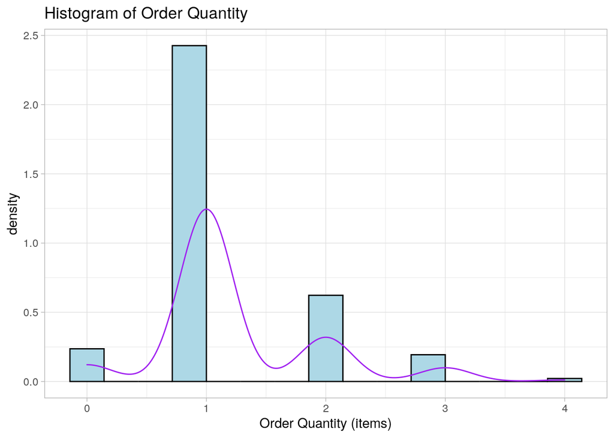

```r
# your plot 1
data1 %>% ggplot(aes(x = `Order Quantity`)) + geom_histogram(aes(y = ..density..,
    ), bins = 15, color = "black", fill = "light blue") + geom_density(color = "purple") +
    xlab("Order Quantity (items)") + scale_x_continuous() + ggtitle("Histogram of Order Quantity") +
    theme_light()
```

This plot is a histogram of Order Quantities from all of the data. You can see which order quantity has the most density. In this case, I buy orders with just 1 item most of the time.

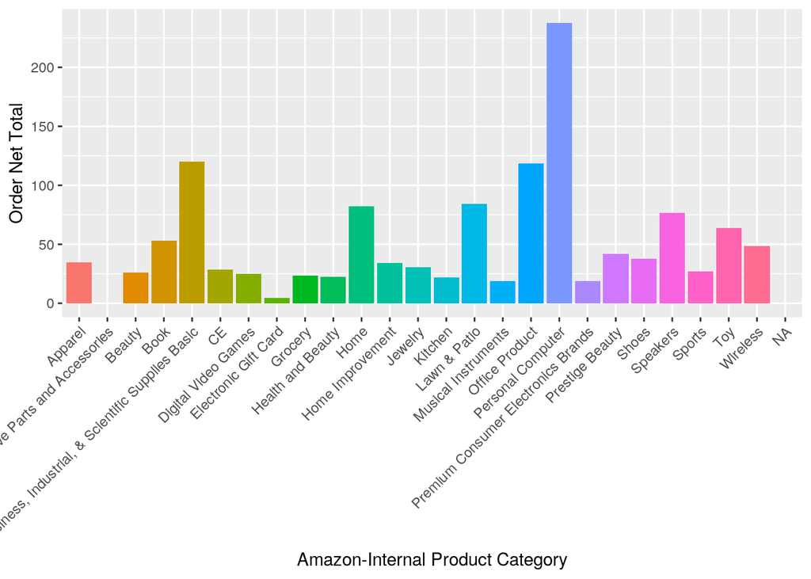

```r
# your plot 2
data3 %>% ggplot(aes(`Amazon-Internal Product Category`)) + geom_bar(aes(y = `Order Net Total`,
    fill = `Amazon-Internal Product Category`), stat = "summary",
    fun = mean) + theme(axis.text.x = element_text(angle = 45,
    hjust = 1), legend.position = "none")
```

In this plot, you can see the order net totals for each amazon-internal product category. You can visually see that I spend the most money on the Personal Computers category. The second most bought category is Office Products or Scientific Supplies.

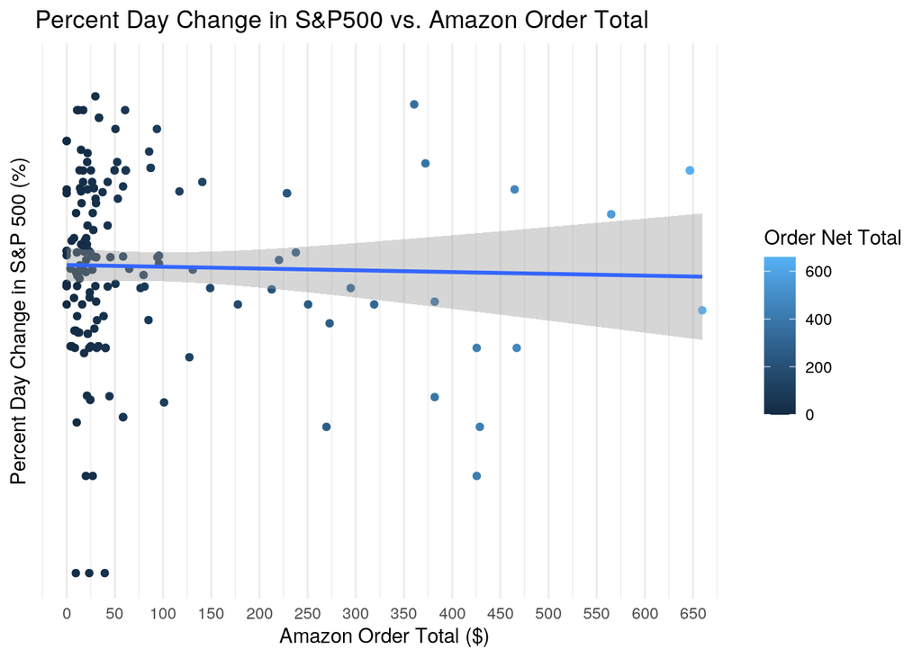

```r
# your plot 3
data3 %>% ggplot(aes(x = `Order Net Total`, y = percent_day_change)) +
    geom_point(aes(color = `Order Net Total`)) + geom_smooth(method = "lm") +
    xlab("Amazon Order Total ($)") + ylab("Percent Day Change in S&P 500 (%)") +
    ggtitle("Percent Day Change in S&P500 vs. Amazon Order Total") +
    theme_minimal() + scale_x_continuous(breaks = seq(0, 800,
    50)) + scale_y_continuous(breaks = seq(50, 200, 10))
```

In this chart, we compared the percent change in the S&P 500 to the amazon order totals. The graph shows that there is basically no correlation between the two variables. I expected to see a positive correlation. In other words, I expected to see higher amazon order totals when the percent day change was higher. However, this was not the case.

#### Concluding Remarks

While I certainly had fun analyzing the data I collected, I was disappointed that there was no correlation to be found.